# Exploratory Data analysis_ RF_MLR

# 7. Correlation of all numerical variables

# rationale: Instead of manually selecting variables based on prior assumptions, I conducted a correlation scan across all numeric variables available in the NFHS-5 dataset. This approach helps identify both expected and unexpected associations with neonatal mortality (NMR).

# Method: I filtered the dataset to include only “Total” area records to avoid rural-urban duplication, then selected only numeric columns. The correlation coefficient of each variable with NMR was computed using Pearson correlation. This is for a data-driven way to screen for predictors before model building (MLR/Random Forest). It ensures that no potential associations are missed, even from variables not initially considered during hypothesis formation.

```r
# Filter to 'Total' and select only numeric variables
df_corr_all <- nfhs5_cleaned %>%
  filter(area == "Total") %>%
  select_if(is.numeric) %>%
  select(neonatal_mortality_rate_per_1000_live_births, everything()) %>%
  na.omit()

# Calculate correlation matrix
cor_nmr <- cor(df_corr_all, use = "complete.obs")

# Extract correlation of all variables with NMR
cor_target <- cor_nmr[, "neonatal_mortality_rate_per_1000_live_births"]

# Sort by absolute value of correlation (strongest associations at the top)
cor_sorted <- sort(cor_target, decreasing = TRUE)

# View top 15 positively and negatively correlated variables
head(cor_sorted, 15)
```

```
##      neonatal_mortality_rate_per_1000_live_births
##                                         1.0000000
##        infant_mortality_rate_per_1000_live_births
##                                         0.9611789
##    under_five_mortality_rate_per_1000_live_births
##                                         0.9358974
##                          men_15_49yr_bmi_below_18
##                                         0.7631137
##                          wmn_15_49yr_bmi_below_18
##                                         0.6993238
##                        pregwmn_15_19yr_anamic_11g
##                                         0.5637037
##                     number_of_households_surveyed
##                                         0.5345078
##       number_of_women_age_15_49_years_interviewed
##                                         0.5342067
##   men_age_25_29_years_married_before_age_21_years
##                                         0.5144601
##                      tetanus_protection_lastbirth
##                                         0.5091732
## total_fertility_rate_number_of_children_per_woman
##                                         0.4964936
##         number_of_men_age_15_54_years_interviewed
##                                         0.4790941
##                                    underweight_u5
##                                         0.4706583
##                   healthwrkr_talk_fem_nonusers_fp
##                                         0.4517342
##   children_age_12_23_months_who_have_received_bcg
##                                         0.4269004
```

```r
tail(cor_sorted, 15)
```

```
##                           men_age_15_49_years_who_have_comprehensive_knowledge24_of_hiv_aids
##                                                                                   -0.3864541
##                                                                  solidsemibm_feed_6_8_months
##                                                                                   -0.4363191
##                                                             female_pop_over6yr_attend_school
##                                                                                   -0.4395166
##                                                     households_using_clean_fuel_for_cooking3
##                                                                                   -0.4488148
## women_age_15_24_years_who_use_hygienic_methods_of_protection_during_their_menstrual_period26
##                                                                                   -0.4498563
##                                                            women_age_15_49_who_are_literate4
##                                                                                   -0.4693841
##                                                                           csec_births_public
##                                                                                   -0.4704658
##                                                                oop_delivery_public_lastbirth
##                                                                                   -0.4801012
##                                                              marriedwmn_15_49yr_fp_iud_ppiud
##                                                                                   -0.4855560
##                                              women_age_15_49_who_have_ever_used_the_internet
##                                                                                   -0.5052925
##                                                          men_15_49yr_bmi_overweight_above_25
##                                                                                   -0.5194352
##                                                                 households_improv_sanitation
##                                                                                   -0.5460238
##                                                                          bf_within_1hr_birth
##                                                                                   -0.5857399
##                                                                            overweight_u5_wfh
##                                                                                   -0.5857766
##                         women_age_15_49_years_having_a_mobile_phone_that_they_themselves_use
##                                                                                   -0.7018689
```

```r
### Correlation Insights: Neonatal Mortality Rate (NMR) and Other Indicators

### Purpose:
#### We are exploring how NMR is associated with other health and demographic indicators. Strong positive or negative correlations help identify potential predictors for modeling.

#### Top 15 Positively Correlated Variables
####  These are the variables that increase along with NMR:

#### Infant Mortality Rate (0.96)
####Under-Five Mortality Rate (0.94)
#### Men BMI < 18 (0.76)
#### Women BMI < 18 (0.70)
#### Pregnant Teen Anaemia (0.56)
#### Tetanus Protection (0.51)
#### Underweight U5 (0.47)


#### Top 15 Negatively Correlated Variables
#### These variables decrease as NMR increases.

#### Women Owning Mobile Phones (-0.70)
#### Overweight U5 (-0.59)
#### Breastfed Within 1 Hour (-0.59)
#### Improved Sanitation (-0.55)
#### Women Using Internet (-0.51)
#### Public C-sections (-0.47)
#### Female Literacy (-0.47)

### Conclusion
#### These correlations help filter relevant predictors for modeling. Variables like **maternal nutrition, service coverage, literacy, and infrastructure show clear relationships with NMR. We will use this to refine our feature set for Random Forest and MLR modeling.



## ----multicollinearity-check-vif, echo=TRUE, message=FALSE, warning=FALSE----

### Explanation:
### We selected the top 15 variables positively and negatively correlated with NMR.
### To ensure these predictors are not highly correlated among themselves,
### we used the Variance Inflation Factor (VIF) to assess multicollinearity.
### VIF > 5 suggests moderate multicollinearity; VIF > 10 indicates strong multicollinearity.
### Variables with high VIFs may be excluded or adjusted for in the regression model.


# Load required package
library(car)
# Select the top 15 positive and 15 negative correlated variables (from previous correlation step)
top_pos_vars <- names(head(cor_sorted, 15))
top_neg_vars <- names(tail(cor_sorted, 15))

# Combine and ensure uniqueness
selected_vars <- unique(c(top_pos_vars, top_neg_vars))

# Prepare data: filter only 'Total' area, select relevant variables, and remove missing values
df_vif <- nfhs5_cleaned %>%
  filter(area == "Total") %>%
  select(all_of(selected_vars)) %>%
  na.omit()

# Fit linear model with NMR as outcome
lm_vif_model <- lm(neonatal_mortality_rate_per_1000_live_births ~ ., data = df_vif)

# Calculate VIF values
vif_values <- vif(lm_vif_model)
print(vif_values)
```

```
##                                                   infant_mortality_rate_per_1000_live_births
##                                                                                   2368.78301
##                                               under_five_mortality_rate_per_1000_live_births
##                                                                                   1294.34033
##                                                                     men_15_49yr_bmi_below_18
##                                                                                    132.44701
##                                                                     wmn_15_49yr_bmi_below_18
##                                                                                   1268.34880
##                                                                   pregwmn_15_19yr_anamic_11g
##                                                                                     25.90246
##                                                                number_of_households_surveyed
##                                                                                   1263.31651
##                                                  number_of_women_age_15_49_years_interviewed
##                                                                                  15344.40784
##                                              men_age_25_29_years_married_before_age_21_years
##                                                                                     49.25047
##                                                                 tetanus_protection_lastbirth
##                                                                                     17.24574
##                                            total_fertility_rate_number_of_children_per_woman
##                                                                                    224.17465
##                                                    number_of_men_age_15_54_years_interviewed
##                                                                                   9501.55591
##                                                                               underweight_u5
##                                                                                    545.45627
##                                                              healthwrkr_talk_fem_nonusers_fp
##                                                                                     22.19564
##                                              children_age_12_23_months_who_have_received_bcg
##                                                                                     68.84194
##                           men_age_15_49_years_who_have_comprehensive_knowledge24_of_hiv_aids
##                                                                                    154.54060
##                                                                  solidsemibm_feed_6_8_months
##                                                                                    205.55910
##                                                             female_pop_over6yr_attend_school
##                                                                                    661.60870
##                                                     households_using_clean_fuel_for_cooking3
##                                                                                    332.34262
## women_age_15_24_years_who_use_hygienic_methods_of_protection_during_their_menstrual_period26
##                                                                                    189.15590
##                                                            women_age_15_49_who_are_literate4
##                                                                                    848.08346
##                                                                           csec_births_public
##                                                                                    172.13164
##                                                                oop_delivery_public_lastbirth
##                                                                                     16.98166
##                                                              marriedwmn_15_49yr_fp_iud_ppiud
##                                                                                     49.20674
##                                              women_age_15_49_who_have_ever_used_the_internet
##                                                                                     41.70344
##                                                          men_15_49yr_bmi_overweight_above_25
##                                                                                     70.10618
##                                                                 households_improv_sanitation
##                                                                                     27.54614
##                                                                          bf_within_1hr_birth
##                                                                                     25.88701
##                                                                            overweight_u5_wfh
##                                                                                     71.65696
##                         women_age_15_49_years_having_a_mobile_phone_that_they_themselves_use
##                                                                                     84.05140
```

```r
## Multicollinearity Check:  Multicollinearity was assessed using the Variance Inflation Factor (VIF) method. VIF values above 5 or 10 indicate high multicollinearity, which can distort regression estimates.

## In our initial VIF check, several variables exhibited very high values (e.g., VIF > 1000), particularly variables that are highly related to our outcome or among themselves. These include overlapping mortality indicators (e.g., IMR and U5MR), population counts, and literacy indicators.

## To ensure the reliability of regression estimates, we will iteratively remove highly collinear variables and retain only those with acceptable VIF levels (< 10).

df_vif_filtered <- df_vif %>%
  select(-infant_mortality_rate_per_1000_live_births,
         -under_five_mortality_rate_per_1000_live_births,
         -number_of_households_surveyed,
         -number_of_men_age_15_54_years_interviewed,
         -number_of_women_age_15_49_years_interviewed)



# Refit linear model without the removed variables
vif_model_updated <- lm(neonatal_mortality_rate_per_1000_live_births ~ ., data = df_vif_filtered)

# Calculate VIF values again
vif_values_updated <- vif(vif_model_updated)

# Print updated VIFs
print(vif_values_updated)
```

```
##                                                                     men_15_49yr_bmi_below_18
##                                                                                    25.017938
##                                                                     wmn_15_49yr_bmi_below_18
##                                                                                    39.677571
##                                                                   pregwmn_15_19yr_anamic_11g
##                                                                                     8.909043
##                                              men_age_25_29_years_married_before_age_21_years
##                                                                                     8.401258
##                                                                 tetanus_protection_lastbirth
##                                                                                     8.620861
##                                            total_fertility_rate_number_of_children_per_woman
##                                                                                    13.372203
##                                                                               underweight_u5
##                                                                                    30.271054
##                                                              healthwrkr_talk_fem_nonusers_fp
##                                                                                     6.154147
##                                              children_age_12_23_months_who_have_received_bcg
##                                                                                     8.557827
##                           men_age_15_49_years_who_have_comprehensive_knowledge24_of_hiv_aids
##                                                                                     8.431021
##                                                                  solidsemibm_feed_6_8_months
##                                                                                     5.762573
##                                                             female_pop_over6yr_attend_school
##                                                                                    29.321697
##                                                     households_using_clean_fuel_for_cooking3
##                                                                                    13.950120
## women_age_15_24_years_who_use_hygienic_methods_of_protection_during_their_menstrual_period26
##                                                                                    10.249277
##                                                            women_age_15_49_who_are_literate4
##                                                                                    34.561046
##                                                                           csec_births_public
##                                                                                     9.587665
##                                                                oop_delivery_public_lastbirth
##                                                                                     6.022221
##                                                              marriedwmn_15_49yr_fp_iud_ppiud
##                                                                                     8.850115
##                                              women_age_15_49_who_have_ever_used_the_internet
##                                                                                    20.976365
##                                                          men_15_49yr_bmi_overweight_above_25
##                                                                                    29.765678
##                                                                 households_improv_sanitation
##                                                                                     7.054533
##                                                                          bf_within_1hr_birth
##                                                                                     5.890995
##                                                                            overweight_u5_wfh
##                                                                                    17.557833
##                         women_age_15_49_years_having_a_mobile_phone_that_they_themselves_use
##                                                                                    29.564743
```

```r
# Remove high multicollinearity variables based on VIF analysis
# Filtering out variables with 'men' in their name and 'healthwrkr_talk_fem_nonusers_fp'
vif_variables <- c(
  "men_15_49yr_bmi_below_18",
  "men_age_25_29_years_married_before_age_21_years",
  "men_age_15_49_years_who_have_comprehensive_knowledge24_of_hiv_aids",
  "men_15_49yr_bmi_overweight_above_25",
  "healthwrkr_talk_fem_nonusers_fp"
)

# Drop these columns from the dataset
nfhs5_cleaned <- nfhs5_cleaned %>%
  select(-all_of(vif_variables))

# 1. Recreate the final list of selected variables (top 15 positive + 15 negative correlated)
top_pos_vars <- names(head(cor_sorted, 15))
top_neg_vars <- names(tail(cor_sorted, 15))
selected_vars <- unique(c(top_pos_vars, top_neg_vars))

# 2. Exclude the high-VIF variables manually removed
vars_to_exclude <- c(
  "infant_mortality_rate_per_1000_live_births",
  "under_five_mortality_rate_per_1000_live_births",
  "number_of_households_surveyed",
  "number_of_women_age_15_49_years_interviewed",
  "number_of_men_age_15_54_years_interviewed",
  "men_15_49yr_bmi_below_18",
  "men_age_25_29_years_married_before_age_21_years",
  "men_age_15_49_years_who_have_comprehensive_knowledge24_of_hiv_aids",
  "men_15_49yr_bmi_overweight_above_25",
  "healthwrkr_talk_fem_nonusers_fp"
)

selected_vars_final <- setdiff(selected_vars, vars_to_exclude)

# 3. Prepare the filtered dataset for VIF
df_vif_final <- nfhs5_cleaned %>%
  filter(area == "Total") %>%
  select(all_of(selected_vars_final)) %>%
  na.omit()

# 4. Fit linear model for VIF checking
library(car)
vif_model_final <- lm(neonatal_mortality_rate_per_1000_live_births ~ ., data = df_vif_final)

# 5. Calculate and print VIF
vif_values_final <- vif(vif_model_final)
print(vif_values_final)
```

```
##                                                                     wmn_15_49yr_bmi_below_18
##                                                                                    20.744687
##                                                                   pregwmn_15_19yr_anamic_11g
##                                                                                     7.828902
##                                                                 tetanus_protection_lastbirth
##                                                                                     6.392408
##                                            total_fertility_rate_number_of_children_per_woman
##                                                                                    11.151033
##                                                                               underweight_u5
##                                                                                    19.297883
##                                              children_age_12_23_months_who_have_received_bcg
##                                                                                     7.570299
##                                                                  solidsemibm_feed_6_8_months
##                                                                                     3.428336
##                                                             female_pop_over6yr_attend_school
##                                                                                    23.361851
##                                                     households_using_clean_fuel_for_cooking3
##                                                                                     5.138778
## women_age_15_24_years_who_use_hygienic_methods_of_protection_during_their_menstrual_period26
##                                                                                     7.439042
##                                                            women_age_15_49_who_are_literate4
##                                                                                    25.822987
##                                                                           csec_births_public
##                                                                                     6.676256
##                                                                oop_delivery_public_lastbirth
##                                                                                     5.891885
##                                                              marriedwmn_15_49yr_fp_iud_ppiud
##                                                                                     5.078358
##                                              women_age_15_49_who_have_ever_used_the_internet
##                                                                                    16.623625
##                                                                 households_improv_sanitation
##                                                                                     6.588729
##                                                                          bf_within_1hr_birth
##                                                                                     4.283899
##                                                                            overweight_u5_wfh
##                                                                                    12.564240
##                         women_age_15_49_years_having_a_mobile_phone_that_they_themselves_use
##                                                                                    18.718483
```

```r
vif_remove_final <- c(
  "wmn_15_49yr_bmi_below_18",
  "underweight_u5",
  "female_pop_over6yr_attend_school",
  "women_age_15_49_who_are_literate4",
  "women_age_15_49_who_have_ever_used_the_internet",
  "overweight_u5_wfh",
  "women_age_15_49_years_having_a_mobile_phone_that_they_themselves_use",
  "total_fertility_rate_number_of_children_per_woman"
)


# Drop final high-VIF variables
df_vif_final_filtered <- df_vif_final %>%
  select(-all_of(vif_remove_final))

# Refit the model
vif_model_final2 <- lm(neonatal_mortality_rate_per_1000_live_births ~ ., data = df_vif_final_filtered)

# Calculate new VIFs
vif_values_final2 <- vif(vif_model_final2)
print(vif_values_final2)
```

```
##                                                                   pregwmn_15_19yr_anamic_11g
##                                                                                     3.799470
##                                                                 tetanus_protection_lastbirth
##                                                                                     2.954008
##                                              children_age_12_23_months_who_have_received_bcg
##                                                                                     4.073443
##                                                                  solidsemibm_feed_6_8_months
##                                                                                     1.577116
##                                                     households_using_clean_fuel_for_cooking3
##                                                                                     2.841637
## women_age_15_24_years_who_use_hygienic_methods_of_protection_during_their_menstrual_period26
##                                                                                     2.817560
##                                                                           csec_births_public
##                                                                                     2.845319
##                                                                oop_delivery_public_lastbirth
##                                                                                     2.146610
##                                                              marriedwmn_15_49yr_fp_iud_ppiud
##                                                                                     1.716930
##                                                                 households_improv_sanitation
##                                                                                     2.672550
##                                                                          bf_within_1hr_birth
##                                                                                     1.825059
```

# Multiple Linear Regression Model (MLR)

## Purpose: To assess the strength and direction of association between selected predictors and neonatal mortality rate (NMR) using a linear model. This helps us understand how individual factors contribute to NMR while controlling for others.

```r
# Fit the MLR model using the final set of variables with low multicollinearity
mlr_model <- lm(neonatal_mortality_rate_per_1000_live_births ~ ., data = df_vif_final_filtered)

# Summarize the model
summary(mlr_model)
```

```
##
## Call:
## lm(formula = neonatal_mortality_rate_per_1000_live_births ~ .,
##     data = df_vif_final_filtered)
##
## Residuals:
##     Min      1Q  Median      3Q     Max
## -6.5000 -2.2465 -0.4493  1.2829  9.1635
##
## Coefficients:
##                                                                                                Estimate
## (Intercept)                                                                                  27.8468244
## pregwmn_15_19yr_anamic_11g                                                                    0.1235296
## tetanus_protection_lastbirth                                                                  0.1655933
## children_age_12_23_months_who_have_received_bcg                                              -0.0211838
## solidsemibm_feed_6_8_months                                                                   0.0815690
## households_using_clean_fuel_for_cooking3                                                     -0.0075110
## women_age_15_24_years_who_use_hygienic_methods_of_protection_during_their_menstrual_period26 -0.0412659
## csec_births_public                                                                           -0.2948954
## oop_delivery_public_lastbirth                                                                -0.0003685
## marriedwmn_15_49yr_fp_iud_ppiud                                                              -0.3553453
## households_improv_sanitation                                                                 -0.1163573
## bf_within_1hr_birth                                                                          -0.2102114
##                                                                                              Std. Error
## (Intercept)                                                                                  38.5848208
## pregwmn_15_19yr_anamic_11g                                                                    0.1581551
## tetanus_protection_lastbirth                                                                  0.3191168
## children_age_12_23_months_who_have_received_bcg                                               0.4924696
## solidsemibm_feed_6_8_months                                                                   0.0314177
## households_using_clean_fuel_for_cooking3                                                      0.0709323
## women_age_15_24_years_who_use_hygienic_methods_of_protection_during_their_menstrual_period26  0.1246253
## csec_births_public                                                                            0.1301516
## oop_delivery_public_lastbirth                                                                 0.0004485
## marriedwmn_15_49yr_fp_iud_ppiud                                                               0.3200992
## households_improv_sanitation                                                                  0.1321388
## bf_within_1hr_birth                                                                           0.0867010
##                                                                                              t value
## (Intercept)                                                                                    0.722
## pregwmn_15_19yr_anamic_11g                                                                     0.781
## tetanus_protection_lastbirth                                                                   0.519
```

[output cut: 26 more lines]

```
## children_age_12_23_months_who_have_received_bcg
## solidsemibm_feed_6_8_months                                                                  *
## households_using_clean_fuel_for_cooking3
## women_age_15_24_years_who_use_hygienic_methods_of_protection_during_their_menstrual_period26
## csec_births_public                                                                           *
## oop_delivery_public_lastbirth
## marriedwmn_15_49yr_fp_iud_ppiud
## households_improv_sanitation
## bf_within_1hr_birth                                                                          *
## ---
## Signif. codes:  0 '***' 0.001 '**' 0.01 '*' 0.05 '.' 0.1 ' ' 1
##
## Residual standard error: 4.772 on 19 degrees of freedom
## Multiple R-squared:  0.8144, Adjusted R-squared:  0.707
## F-statistic:  7.58 on 11 and 19 DF,  p-value: 7.251e-05
```

```r
# Acquire the bigger summary with CI
library(broom)
tidy(mlr_model, conf.int = TRUE)
```

```
## # A tibble: 12 × 7
##    term                  estimate std.error statistic p.value conf.low conf.high
##    <chr>                    <dbl>     <dbl>     <dbl>   <dbl>    <dbl>     <dbl>
##  1 (Intercept)            2.78e+1 38.6         0.722   0.479  -5.29e+1   1.09e+2
##  2 pregwmn_15_19yr_anam…  1.24e-1  0.158       0.781   0.444  -2.07e-1   4.55e-1
##  3 tetanus_protection_l…  1.66e-1  0.319       0.519   0.610  -5.02e-1   8.34e-1
##  4 children_age_12_23_m… -2.12e-2  0.492      -0.0430  0.966  -1.05e+0   1.01e+0
##  5 solidsemibm_feed_6_8…  8.16e-2  0.0314      2.60    0.0177  1.58e-2   1.47e-1
##  6 households_using_cle… -7.51e-3  0.0709     -0.106   0.917  -1.56e-1   1.41e-1
##  7 women_age_15_24_year… -4.13e-2  0.125      -0.331   0.744  -3.02e-1   2.20e-1
##  8 csec_births_public    -2.95e-1  0.130      -2.27    0.0353 -5.67e-1  -2.25e-2
##  9 oop_delivery_public_… -3.69e-4  0.000448   -0.822   0.421  -1.31e-3   5.70e-4
## 10 marriedwmn_15_49yr_f… -3.55e-1  0.320      -1.11    0.281  -1.03e+0   3.15e-1
## 11 households_improv_sa… -1.16e-1  0.132      -0.881   0.390  -3.93e-1   1.60e-1
## 12 bf_within_1hr_birth   -2.10e-1  0.0867     -2.42    0.0255 -3.92e-1  -2.87e-2
```

```r
## 8. Multiple Linear Regression (MLR) to Predict Neonatal Mortality

### To explore the influence of selected health system and demographic variables on neonatal mortality rate (NMR), we ran a multiple linear regression using 11 predictors identified from correlation analysis and VIF filtering.

### The model had an **Adjusted R² of 0.707, indicating that 71% of the variation in NMR across states could be explained by the selected variables.

### Significant negative associations were found for:
### Early breastfeeding initiation,
### C-section births in public facilities, and
### positive association** with early complementary feeding practices.

### These findings align with global evidence, reinforcing the importance of maternal and newborn care interventions.

### Non-significant predictors such as maternal anaemia, sanitation, or hygienic practices during menstruation may need deeper contextual exploration.
```

## Interpretation:

##The **coefficients** show the estimated change in NMR per unit change in each predictor, holding others constant. - **p-values** indicate statistical significance (*p < 0.05 typically considered significant*). - **R-squared** and **Adjusted R-squared** indicate how much variance in NMR is explained by the model.

## Diagnostics:

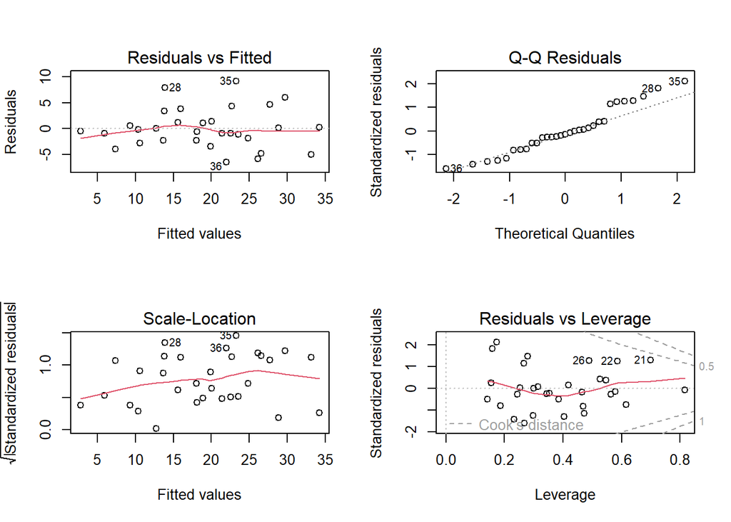

```r
par(mfrow = c(2, 2))
plot(mlr_model)
```

- **Residual plots** help assess the assumptions of linearity, homoscedasticity, and normality. - If assumptions are violated, consider transforming variables or switching to non-linear models like Random Forest.

# 8. Random Forest Regression

## Rationale:

While Multiple Linear Regression (MLR) provides interpretability, Random Forest (RF) is a powerful machine learning technique that can capture non-linear relationships and interactions between variables. RF is particularly useful in public health datasets like NFHS-5, where predictors may have complex, non-linear effects on outcomes such as Neonatal Mortality Rate (NMR).

This step helps us understand variable importance and strengthens the robustness of our predictive modeling.

## Model Execution

Explaination: Random Forest: Data Preparation and Splitting Before building the Random Forest model, the dataset was filtered to remove variables with high multicollinearity (based on VIF) and missing values.

The dataset was then split into two parts: 80% training data and 20% testing data using random sampling.

The training set was used to train the model, and the testing set was used to evaluate model performance.

A random seed (set.seed(123)) was applied to ensure reproducibility.

This approach ensures that the model is trained on one part of the data and validated on a separate part, helping to check for overfitting.

```r
# Load necessary libraries
library(randomForest)
library(caret)
# Prepare the dataset (already filtered for VIF and missing values)
df_rf <- df_vif_final_filtered


# Set seed for reproducibility
set.seed(123)

# Split the data: 80% training, 20% testing
train_index <- createDataPartition(df_rf$neonatal_mortality_rate_per_1000_live_births, p = 0.8, list = FALSE)
train_data <- df_rf[train_index, ]
test_data <- df_rf[-train_index, ]
```

### Fitting the model in the training set

After preparing the training dataset, we built the Random Forest model to predict Neonatal Mortality Rate (NMR) across Indian states.

Model Training: A Random Forest regression model was initially trained using 500 trees with default settings. Variable importance was calculated during model training.

Hyperparameter Tuning (mtry selection): The optimal value of mtry (number of variables considered at each split) was identified using the tuneRF() function. This step improves model accuracy by finding the best balance between bias and variance.

Refitting the Model: The Random Forest model was refitted using:

500 trees initially,

mtry = 4 (optimal value from tuning),

Then also trained separately using a reduced number of 300 trees to simplify the model while maintaining performance.

Variable Importance Plot: After model fitting, variable importance scores (based on node purity) were extracted. A bar plot was created to rank predictors from highest to lowest importance, making it easier to interpret key drivers of neonatal mortality.

Comparison with MLR Predictors: Finally, the top predictors identified through Random Forest were compared with those identified in the Multiple Linear Regression (MLR) model. This comparison helps in cross-validating important variables across two different modeling approaches.

```
## mtry = 3  OOB error = 42.88866
## Searching left ...
## mtry = 2     OOB error = 43.16867
## -0.006528719 0.01
## Searching right ...
## mtry = 4     OOB error = 40.24368
## 0.06167086 0.01
## mtry = 6     OOB error = 46.29065
## -0.1502589 0.01
```

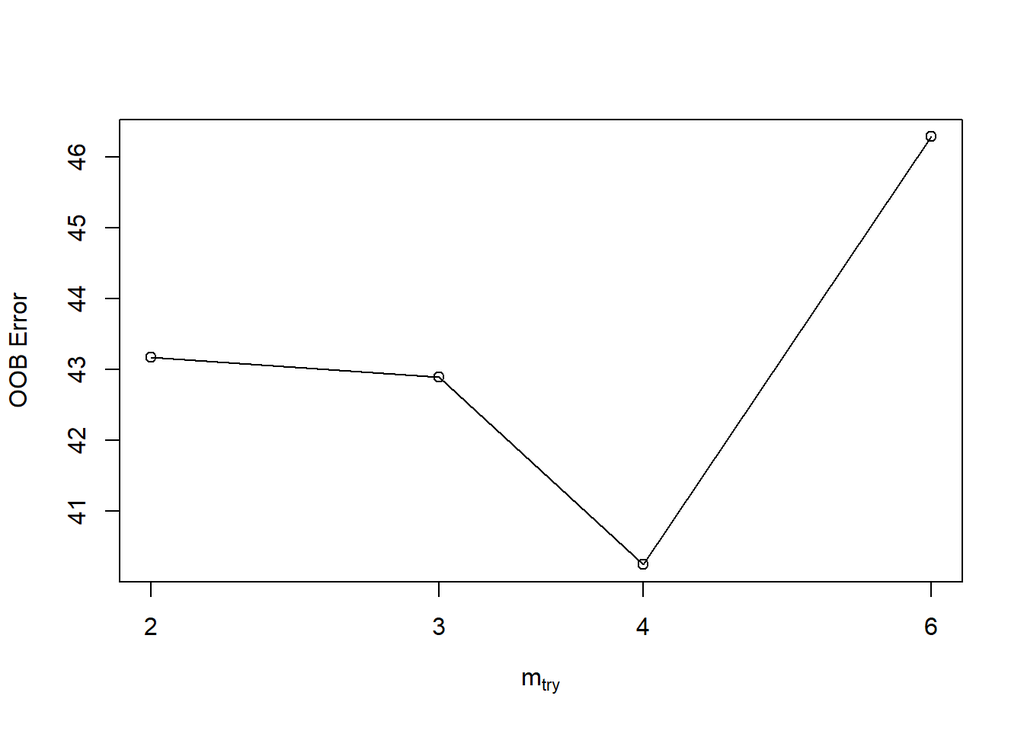

```r
# Train the Random Forest model
rf_model <- randomForest(
  neonatal_mortality_rate_per_1000_live_births ~ .,
  data = train_data,
  importance = TRUE,
  ntree = 500
)

best_mtry <- tuneRF(
  x = train_data[ , -which(names(train_data) == "neonatal_mortality_rate_per_1000_live_births")],
  y = train_data$neonatal_mortality_rate_per_1000_live_births,
  stepFactor = 1.5,
  improve = 0.01,
  trace = TRUE,
  plot = TRUE
)
```

```r
# Refit Random Forest model with best mtry
set.seed(123)
rf_model_tuned <- randomForest(
  neonatal_mortality_rate_per_1000_live_births ~ .,
  data = train_data,
  importance = TRUE,
  ntree = 500,
  mtry = 4
)

# Print the model summary
print(rf_model_tuned)
```

```
##
## Call:
##  randomForest(formula = neonatal_mortality_rate_per_1000_live_births ~      ., data = train_data, importance = TRUE, ntree = 500, mtry = 4)
##                Type of random forest: regression
##                      Number of trees: 500
## No. of variables tried at each split: 4
##
##           Mean of squared residuals: 38.85995
##                     % Var explained: 45.21
```

```r
# Train Random Forest with reduced number of trees (e.g., 200)

rf_model_small <- randomForest(
  formula = neonatal_mortality_rate_per_1000_live_births ~ .,
  data = train_data,
  importance = TRUE,
  ntree = 300,   # Reduced number of trees
  mtry = 4       # Optimal mtry from tuning
)

# Summary
print(rf_model_small)
```

```
##
## Call:
##  randomForest(formula = neonatal_mortality_rate_per_1000_live_births ~      ., data = train_data, importance = TRUE, ntree = 300, mtry = 4)
##                Type of random forest: regression
##                      Number of trees: 300
## No. of variables tried at each split: 4
##
##           Mean of squared residuals: 41.16736
##                     % Var explained: 41.96
```

[figure not shown]

```r
# Plot the variable importance
varImpPlot(rf_model_small)
```

[figure not shown]

```r
library(ggplot2)

# Extract variable importance (MeanDecreaseGini)
var_imp <- importance(rf_model_small)
var_imp_df <- data.frame(Variable = rownames(var_imp),
                         Importance = var_imp[, "IncNodePurity"])

# Arrange in descending order
var_imp_df <- var_imp_df %>%
  arrange(desc(Importance))

# Plot using ggplot2
ggplot(var_imp_df, aes(x = reorder(Variable, Importance), y = Importance)) +
  geom_col(fill = "darkgreen") +
  coord_flip() +
  labs(title = "Variable Importance in Random Forest Model",
       x = "Variables", y = "Node Purity (Importance)") +
  theme_minimal(base_size = 14) +                           # Clean, bigger text
  theme(
    axis.text.y = element_text(size = 12),                  # Bigger labels
    plot.title = element_text(hjust = 0.5, face = "bold"),  # Centered bold title
    panel.grid.major.y = element_blank()                    # Remove horizontal gridlines
  )
```

```r
# Top predictors based on MLR significance (p < 0.05)
top_mlr_vars <- c("solidsemibm_feed_6_8_months",
                  "csec_births_public",
                  "bf_within_1hr_birth")

# Top predictors based on RF variable importance
top_rf_vars <- c("pregwmn_15_19yr_anamic_11g",
                 "bf_within_1hr_birth",
                 "csec_births_public",
                 "households_using_clean_fuel_for_cooking3",
                 "households_improv_sanitation")

# Create comparison table
comparison_df <- data.frame(
  `MLR Predictors` = c(top_mlr_vars, rep("", length(top_rf_vars) - length(top_mlr_vars))),
  `Random Forest Predictors` = top_rf_vars
)

# Display as a table
knitr::kable(comparison_df, caption = "Comparison of Top Predictors from MLR and RF")
```

Comparison of Top Predictors from MLR and RF

| MLR.Predictors | Random.Forest.Predictors |
| --- | --- |
| solidsemibm_feed_6_8_months | pregwmn_15_19yr_anamic_11g |
| csec_births_public | bf_within_1hr_birth |
| bf_within_1hr_birth | csec_births_public |
|  | households_using_clean_fuel_for_cooking3 |
|  | households_improv_sanitation |

# 8. Comparison of MLR and Random Forest Predictors

```r
# Top variables based on MLR significance
top_mlr_vars <- c("solidsemibm_feed_6_8_months", "csec_births_public", "bf_within_1hr_birth")

# Top variables based on RF importance plot
top_rf_vars <- c("pregwmn_15_19yr_anamic_11g", "bf_within_1hr_birth", "csec_births_public",
                 "households_using_clean_fuel_for_cooking3", "households_improv_sanitation")

# Combine into a table
comparison_df <- data.frame(
  MLR = c(top_mlr_vars, rep("", length(top_rf_vars) - length(top_mlr_vars))),
  RF = top_rf_vars
)

# Show the table
comparison_df
```

```
##                           MLR                                       RF
## 1 solidsemibm_feed_6_8_months               pregwmn_15_19yr_anamic_11g
## 2          csec_births_public                      bf_within_1hr_birth
## 3         bf_within_1hr_birth                       csec_births_public
## 4                             households_using_clean_fuel_for_cooking3
## 5                                         households_improv_sanitation
```

```r
# Predict on the test set
pred_rf <- predict(rf_model_small, newdata = test_data)

# Calculate RMSE and R-squared
rf_perf <- postResample(pred = pred_rf, obs = test_data$neonatal_mortality_rate_per_1000_live_births)
print(rf_perf)
```

```
##      RMSE  Rsquared       MAE
## 7.4447779 0.9513474 5.6270653
```

Model Evaluation Metrics: RF vs MLR

```r
### 1. Random Forest Predictions and Metrics
# Predict on the test set
pred_rf <- predict(rf_model_small, newdata = test_data)

# Actual values
actual_rf <- test_data$neonatal_mortality_rate_per_1000_live_births

# Calculate RMSE, R², MAE
rf_metrics <- data.frame(
  RMSE = RMSE(pred_rf, actual_rf),
  Rsquared = R2(pred_rf, actual_rf),
  MAE = MAE(pred_rf, actual_rf)
)

print(rf_metrics)
```

```
##       RMSE  Rsquared      MAE
## 1 7.444778 0.9513474 5.627065
```

```r
### 2. Multiple Linear Regression Predictions and Metrics
# Split MLR data again (same 80/20 split as RF)
set.seed(123)
mlr_index <- createDataPartition(df_vif_final_filtered$neonatal_mortality_rate_per_1000_live_births, p = 0.8, list = FALSE)
mlr_train <- df_vif_final_filtered[mlr_index, ]
mlr_test <- df_vif_final_filtered[-mlr_index, ]

# Fit the model
mlr_model_split <- lm(neonatal_mortality_rate_per_1000_live_births ~ ., data = mlr_train)

# Predict on test data
pred_mlr <- predict(mlr_model_split, newdata = mlr_test)
actual_mlr <- mlr_test$neonatal_mortality_rate_per_1000_live_births

# Calculate metrics
mlr_metrics <- data.frame(
  RMSE = RMSE(pred_mlr, actual_mlr),
  Rsquared = R2(pred_mlr, actual_mlr),
  MAE = MAE(pred_mlr, actual_mlr)
)

print(mlr_metrics)
```

```
##       RMSE  Rsquared      MAE
## 1 5.134583 0.9352366 4.454626
```

## SPATIAL VARIABILITY

To understand the geographical distribution of neonatal mortality, a choropleth map was created by merging NFHS-5 neonatal mortality data with state-level spatial shapefiles. This visualization highlights regional disparities in newborn survival across India.

```r
# install 'sf' package if not installed
library(sf)
```

```r
# Read India states shapefile
india_states <- st_read("C:/Users/HP/OneDrive/Documents/MAPS GITHUB/Admin2.shp")
# View basic structure
head(india_states)
```

```
## Simple feature collection with 6 features and 1 field
## Geometry type: MULTIPOLYGON
## Dimension:     XY
## Bounding box:  xmin: 74.08569 ymin: 11.59458 xmax: 97.4115 ymax: 30.79527
## Geodetic CRS:  WGS 84
##               ST_NM                       geometry
## 1 Arunachal Pradesh MULTIPOLYGON (((96.08866 29...
## 2             Assam MULTIPOLYGON (((95.97166 27...
## 3        Chandigarh MULTIPOLYGON (((76.77175 30...
## 4         Karnataka MULTIPOLYGON (((77.32647 18...
## 5           Manipur MULTIPOLYGON (((94.57315 25...
## 6         Meghalaya MULTIPOLYGON (((91.82534 26...
```

```r
names(india_states)
```

```
## [1] "ST_NM"    "geometry"
```

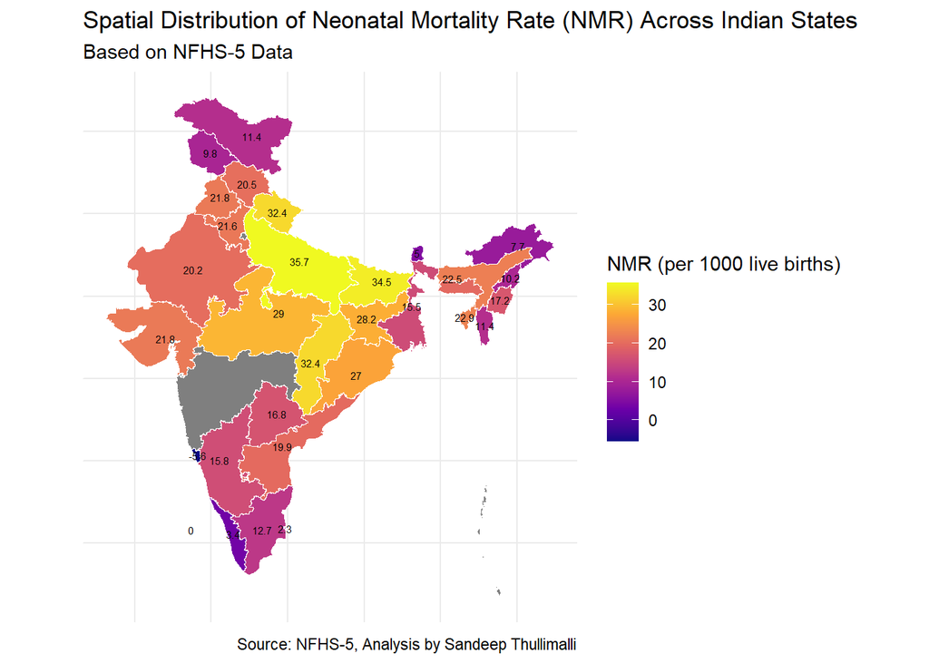

```r
# Merge India states shapefile with your NMR dataset
library(dplyr)
map_data <- india_states %>%
  left_join(nmr_data, by = c("ST_NM" = "states_uts"))


# Plot the map

# Use point on surface instead of centroid
map_data_centroids <- st_point_on_surface(map_data)
# Plot
ggplot(map_data) +
  geom_sf(aes(fill = neonatal_mortality_rate_per_1000_live_births), color = "white", size = 0.2) +
  geom_text(
    data = map_data_centroids,
    aes(x = st_coordinates(geometry)[,1], y = st_coordinates(geometry)[,2],
        label = round(neonatal_mortality_rate_per_1000_live_births, 1)),
    size = 2, color = "black", check_overlap = TRUE
  ) +
  scale_fill_viridis_c(option = "C", name = "NMR (per 1000 live births)") +
  labs(
    title = "Spatial Distribution of Neonatal Mortality Rate (NMR) Across Indian States",
    subtitle = "Based on NFHS-5 Data",
    caption = "Source: NFHS-5, Analysis by Sandeep Thullimalli"
  ) +
  theme_minimal() +
  theme(
    axis.text = element_blank(),
    axis.title = element_blank(),
    axis.ticks = element_blank()
  )
```

```r
# Explaination: A choropleth map was generated to visualize the spatial distribution of Neonatal Mortality Rate (NMR) across Indian states based on NFHS-5 data. Higher NMR values were observed in central and northern regions, while southern and northeastern states generally exhibited lower rates. The map highlights the need for region-specific public health interventions to reduce neonatal mortality.
```

Summary of Findings This analysis used data from NFHS-5 to explore factors associated with Neonatal Mortality Rate (NMR) across Indian states. Through a combination of correlation analysis, multicollinearity checks, and predictive modeling using Multiple Linear Regression (MLR) and Random Forest (RF), we derived the following insights:

1. Early initiation of breastfeeding
2. Public facility caesarean section coverage
3. Complementary feeding practices

The most important RF predictors based on variable importance are :

Model Performance

Interpretation and Implications Maternal and newborn care practices, such as timely breastfeeding and institutional births, show strong protective associations with NMR.

Infrastructure and socioeconomic factors like sanitation and access to clean fuels also emerged as important.

The combined use of MLR for interpretability and RF for robustness enhances the validity of the findings.